# When can per-site phyloP make a call?

The statistics of single-nucleotide conservation tests — why a deep tree isn't enough on its own, and why the number of species you have sets a hard ceiling.

Per-site [phyloP](https://doi.org/10.1101/gr.097857.109) asks, one alignment column at a time, whether that single base is evolving more slowly than neutral expectation. It is a hypothesis test at every site, so a genome-wide run performs millions of them, and the results are corrected for multiple testing. That correction has a consequence people rarely state out loud: on some datasets *no site can pass, however perfectly conserved it is* — not because the pipeline is broken, but because the test simply lacks the statistical power. This page derives exactly where that line falls.

The whole story reduces to one inequality, and the two sides of it are different in kind.

**A single site is detectable if and only if**

\[ \underbrace{\text{ceiling}(T,\,\text{model},\,n)}_{\text{biology: the best score attainable}} \;\;\ge\;\; \underbrace{\log_{10}(M/\alpha)}_{\text{bookkeeping: the bar to clear}} \]

\(T\) = total neutral tree depth (sum of branch lengths, in substitutions/site) · \(n\) = number of taxa · \(M\) = number of sites tested · \(\alpha\) = FDR level (`phylop_alpha`, default 0.05).

The right side is pure **bookkeeping** — it depends only on how many tests you ran. The left side is pure **biology** — the strongest signal your tree can physically produce. A site is called only when the biology out-scores the bookkeeping. We take the two sides in turn.

## The bar — how much the correction costs you

With \(M\) sites tested and a target false-discovery rate \(\alpha\), the single most significant site in the whole genome has to reach \(p \le \alpha/M\) (the rank-1 case of the Benjamini–Hochberg procedure; the same threshold Bonferroni would set for the top test). Writing it in the \(-\log_{10}\) units phyloP reports scores in:

\[ \text{bar}(M,\alpha) \;=\; -\log_{10}(\alpha/M) \;=\; \log_{10}(M/\alpha) \]

This is exact and has nothing to do with evolution. The one thing to take from it: **testing fewer sites lowers the bar.** Screen a few hundred candidate regions and the bar is low; scan a whole genome and it is high. Nothing you do to the *tree* changes this side — it is set entirely by how many tests you chose to run.

## The ceiling — the best score the tree can produce

The most extreme evidence a single column could ever show is *perfect* conservation: every species carrying the identical base. The ceiling is the \(-\log_{10}\) p-value that ideal column would earn on your fitted neutral tree. No real site can beat it, so if the ceiling itself falls below the bar, the dataset cannot call a single conserved site no matter what.

The key fact — and the reason this page exists — is that the ceiling is **not** a function of tree depth alone. It is governed by a race between two limits:

\[ \text{LRT}_{\max} \;\approx\; \min\!\Big(\; \underbrace{2\,\kappa\,T}_{\text{depth-limited}}\;,\;\; \underbrace{2\,(n-1)\ln 4}_{\text{taxon-limited}}\;\Big), \qquad \text{ceiling} \;=\; -\log_{10}\operatorname{erfc}\!\big(\sqrt{\text{LRT}_{\max}/2}\big) \]

\(\text{LRT}_{\max}\) is the likelihood-ratio test statistic for a perfectly conserved column; the `erfc` expression is just the map from that statistic to a p-value (details below). What matters is the `min`: whichever of the two limits is smaller wins.

### Limit 1 — depth, and the only thing the model contributes

More tree depth means more expected substitutions, so a column that *didn't* change is more surprising — the score climbs with \(T\). The substitution model enters here through a single number \(\kappa\), the fastest per-base substitution rate once the model is normalized to an average rate of 1.

- \(\kappa = 1\) exactly for a flat Jukes–Cantor model (all bases turn over equally).
- \(\kappa > 1\) for every realistic model — unequal base frequencies, transition/transversion bias, and GC content all make some bases turn over faster. Fitted vertebrate models sit in a narrow \(\kappa \approx 1.3\text{–}1.5\).

Because \(\kappa\) only multiplies \(T\), it simply **stretches the depth axis**: a structured model detects like a tree \(\kappa\) times deeper. That's the whole influence of "which model you use" — small, and it never changes the shape of the answer.

### Limit 2 — taxa, and the wall you cannot climb

Here is the part that surprises people. \(T\) is the *total* substitutions across the tree, but a tree can only supply as many independent observations as it has species. If you inflate \(T\) by making branches longer, they *saturate*: the two ends of a long branch become statistically independent, each just a random draw from the equilibrium base composition. A perfectly conserved column is then nothing more than \(n\) independent one-in-four coincidences — worth a fixed amount of evidence, \(2(n-1)\ln 4\), **no matter how deep the tree gets.**

Past that point, adding depth does nothing. In the figure below this shows up as a horizontal **taxon wall**: the largest testing burden \(M\) that a given number of species can ever handle, even with an infinitely deep tree, is

\[ M_{\text{wall}}(n) \;=\; \alpha\cdot 10^{\,\text{cap}(n)}, \qquad \text{cap}(n) \;=\; -\log_{10}\operatorname{erfc}\!\big(\sqrt{(n-1)\ln 4}\big). \]

Above that line no site is callable at any depth. And the wall climbs steeply — roughly a factor of four in \(M\) for every species you add:

| taxa \(n\) | ceiling cap (\(-\log_{10}p\)) | taxon wall \(M_{\text{wall}}\) |
| --- | --- | --- |
| 8 | ≈ 5.0 | ≈ 5 × 10³ sites |
| 12 | ≈ 7.5 | ≈ 1.5 × 10⁶ |
| 15 | ≈ 9.3 | ≈ 1 × 10⁸ |
| 20 | ≈ 12.4 | ≈ 1 × 10¹¹ |

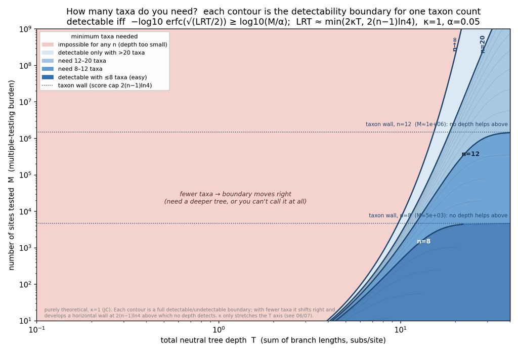

**Depth versus taxa.** Each contour is a full detectable/undetectable boundary, but for a different number of species (thick lines n = 8, 12, 20; thin dotted lines fill in every n from 1 to 20). Shading gives the *minimum* taxa needed to make a call at each point. Reading horizontally: with fewer species the boundary shifts right — you need a deeper tree to compensate. Reading vertically: each finite-\(n\) boundary eventually flattens into its taxon wall, above which no depth helps. Depth is the slope you climb; taxon count is the ceiling you hit.

## Putting the two together

The practical rule falls straight out of the walls. To run a genome-wide scan you are testing on the order of \(M \sim 10^8\) sites, so you need a taxon wall above \(10^8\) — that is, roughly **\(n \gtrsim 15\) species** — *and* a tree deep enough to reach the boundary at that \(M\). With only a handful of species the wall sits far below genome scale, and no depth rescues it: such a dataset can still screen a small, targeted set of candidate regions (small \(M\), low bar), but never the whole genome.

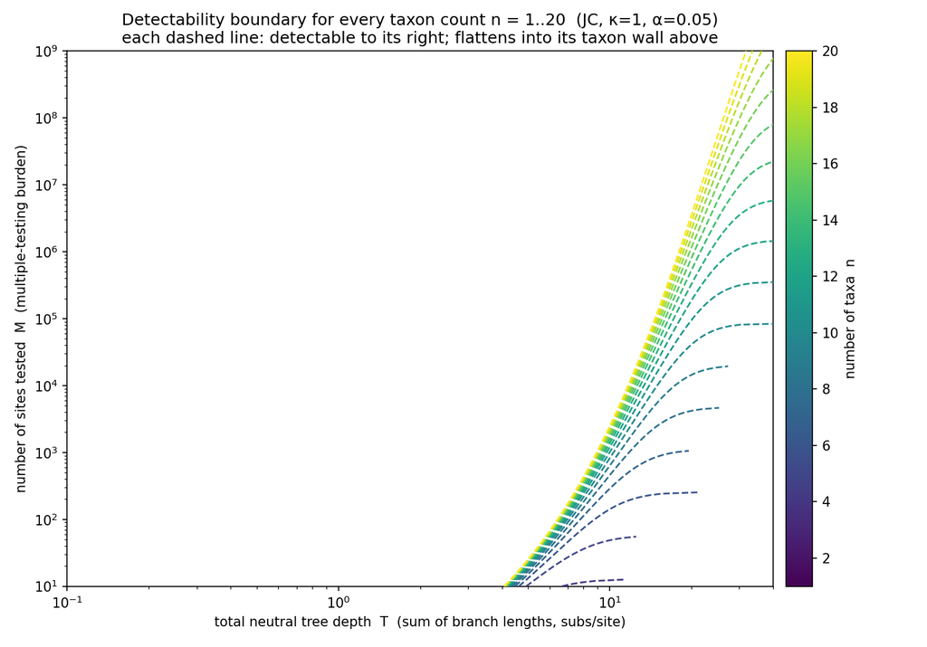

**Every taxon count, 1–20.** The same boundary drawn once per number of species (color = \(n\)). The fan makes the "×4 per taxon" scaling of the walls visible: low-\(n\) lines flatten almost immediately at tiny \(M\); high-\(n\) lines climb off the top of the plot because their walls lie far above genome scale. Lines for \(n = 1\text{–}3\) never appear — their walls fall below \(M = 10\), and a single sequence (\(n=1\)) carries no conservation signal at all.

This is not an abstraction: it is exactly why per-site phyloP returns essentially *zero* conserved sites on shallow, species-poor alignments (hamsters, birds, turtles — a dozen-ish taxa) while returning millions on the 241-species Zoonomia mammal alignment. Same method, same code; the difference is entirely which side of the taxon wall the dataset sits on. The pipeline's pre-flight power gate checks this inequality up front and stops the phyloP branch early, with an informative message, rather than spending hours to produce an empty result.

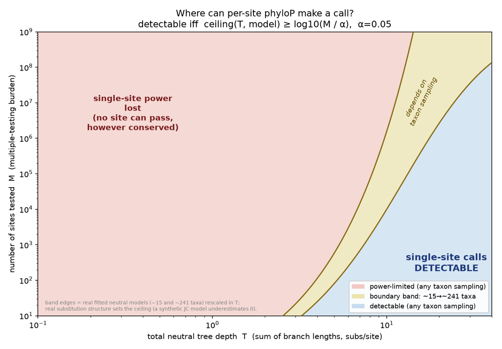

**The same picture from real fitted models.** Rather than the idealized \(\kappa\)-and-\(n\) knobs, this version draws the boundary band from two genuine fitted neutral models of contrasting taxon count (a sparse ~15-species tree and a dense ~241-species tree), rescaled in depth. The band between them is the honest taxon-sampling spread — confirming the theory above lands where real data does.

**For the curious — how the ceiling is actually computed**

The closed forms above are the two *limiting* regimes; the exact ceiling interpolates between them and is what the scripts compute. For a perfectly conserved column (all species = base \(b\)) the likelihood-ratio statistic is

\[ \text{LRT}_b = 2\big[\log \pi_b - \log P(\text{all leaves}=b \mid \text{neutral})\big], \qquad \text{LRT}_{\max} = \max_b \text{LRT}_b, \]

where \(P(\text{all leaves}=b)\) is evaluated by **Felsenstein's pruning algorithm** on the fitted tree (branch lengths uniformly rescaled to total depth \(T\)) using the fitted rate matrix \(Q\), with transition probabilities \(P(t)=e^{Qt}\). The p-value uses the \(\chi^2_1\) upper tail (phyloP's two-sided `CONACC` convention, validated against the phyloP binary):

\[ \text{ceiling} = -\log_{10}\operatorname{erfc}\!\big(\sqrt{\text{LRT}_{\max}/2}\big). \]

As branches shorten (many taxa) this collapses to \(\text{LRT}_{\max}\to 2\kappa T\); as they lengthen (few taxa) it saturates at \(2(n-1)\ln 4\). A fully explicit special case is Jukes–Cantor on a star tree of \(n\) tips at depth \(T\), which needs no fitted model at all:

\[ \text{LRT}_{\max}(n,T) = -2\ln\!\big(P_{\text{same}}^{\,n} + 3\,P_{\text{diff}}^{\,n}\big),\quad P_{\text{same}}=\tfrac14+\tfrac34 e^{-4T/3n},\;\; P_{\text{diff}}=\tfrac14-\tfrac14 e^{-4T/3n}. \]

**Caveats.** Rescaling a fitted model far from its own depth extrapolates its shape; the ceiling is a best case (a perfectly conserved column at the most informative base), so it is an upper bound on real per-site scores — which is exactly what a detectability limit should be.

Reproducible source lives alongside this page in `analyses/phylop-tree-length-power/`: the boundary maps are built by `08_taxon_walls.py` and `09_taxon_line_family.py`, the real-model band by `06_generic_detectability.py`, and the ceiling/erfc math by `lib/phylop_power.py`. The plain-text derivation is `MATH.md` in the same folder.